# IODS course project

Pekka Vartiainen

# About the project

*Write a short description about the course and add a link to your github repository here. This is an R markdown (.Rmd) file so you can use R markdown syntax. See the ‘Useful links’ page in the mooc area (chapter 1) for instructions.*

The course seems really interesting. It’s cool that we have an enthusiastic teacher. I wonder if many researchers in medicine use R markdown?

Took my first steps with R markdown and Github today. Haven’t managed to change the theme of GitHub pages, this is top priority so I’m working on it.

[Link to my repository.](https://github.com/pecsimax/IODS-project)

# Chapter 2: Regression and model validation excercise

*On tuesday, I did the data wrangling excercises and on wednesday, the data analysis tasks. I have some prior experience in working with dplyr, so the wrangling part was not too challenging, but it was great refreshment. For example, I realised that in dplyr, it’s not too easy to calculate “rowMeans” -style of functions selecting only a part of the file - the best way to do it was by first selecting a part of dataset.*

### Here begins the code

setup, setting the working directory and opening the data

```r
 ## change the working directory of this r markdown file
knitr::opts_chunk$set(root.dir = "/Users/pecsi_max/Desktop/GitHub/IODS-project/data/")
setwd("/Users/pecsi_max/Desktop/GitHub/IODS-project/data/")
getwd()

#load the required packages
library(ggplot2)
library(GGally)
library(dplyr)
```

Opening the data *“tbl_df” converts the data frame to a “data table” -format. To my knowledge, it is recommended when using dplyr, although I believe that in these excercises it’s not a big difference.*

```r
#read the data.

learn <- tbl_df(read.csv("/Users/pecsi_max/Desktop/GitHub/IODS-project/data/learning2014.csv"))

#structure of data
str(learn)
```

```
## Classes 'tbl_df', 'tbl' and 'data.frame':    166 obs. of  7 variables:
##  $ gender  : Factor w/ 2 levels "F","M": 1 2 1 2 2 1 2 1 2 1 ...
##  $ age     : int  53 55 49 53 49 38 50 37 37 42 ...
##  $ attitude: int  37 31 25 35 37 38 35 29 38 21 ...
##  $ deep    : num  3.58 2.92 3.5 3.5 3.67 ...
##  $ surf    : num  2.58 3.17 2.25 2.25 2.83 ...
##  $ stra    : num  3.38 2.75 3.62 3.12 3.62 ...
##  $ points  : int  25 12 24 10 22 21 21 31 24 26 ...
```

```r
#dimensions of data
dim(learn)
```

```
## [1] 166   7
```

#### About the data

“learn” is a dataset of 166 students, with variables “gender”, “age”, “attitude”, “points”, “deep”, “stra” and “surf”. Last three are scales measuring different aspects of learning (deep, strategic or surface learning). The students scoring 0 points on exam are not included.

#### Exploring the data

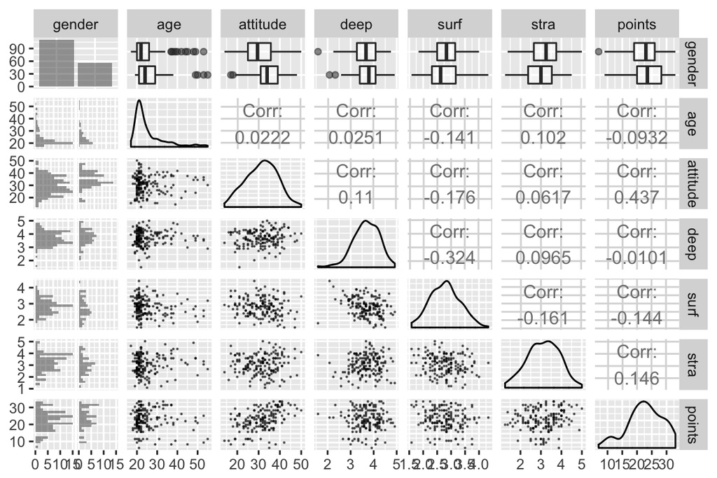

```r
#create a plot matrix with all the variables
pairs_plot <- ggpairs(learn, mapping = aes(alpha = 0.5),
                      lower = list(combo = wrap("facethist", bins = 20),
                                   continuous = wrap("points", size=0.1)),
                      upper = list(continuous = wrap("cor", alpha = 1)))
pairs_plot
```

#### Comments on preliminary associations

##### Different aspects of learning and points

- Strategic learning slightly positively correlated with poits
- Deep learning not correlated with points
- Surface learning negatively correlated with points
- Correlations of attitude and these aspects of learning are similar

### Linear regression model

#### Model 1

```r
#construct a model, choosing 3 variables as dependent vars: attitude, surface learning, strategic learning
model1 <- lm(points ~ attitude + stra + surf, data = learn)
summary(model1)
```

```
##
## Call:
## lm(formula = points ~ attitude + stra + surf, data = learn)
##
## Residuals:
##      Min       1Q   Median       3Q      Max
## -17.1550  -3.4346   0.5156   3.6401  10.8952
##
## Coefficients:
##             Estimate Std. Error t value Pr(>|t|)
## (Intercept) 11.01711    3.68375   2.991  0.00322 **
## attitude     0.33952    0.05741   5.913 1.93e-08 ***
## stra         0.85313    0.54159   1.575  0.11716
## surf        -0.58607    0.80138  -0.731  0.46563
## ---
## Signif. codes:  0 '***' 0.001 '**' 0.01 '*' 0.05 '.' 0.1 ' ' 1
##
## Residual standard error: 5.296 on 162 degrees of freedom
## Multiple R-squared:  0.2074, Adjusted R-squared:  0.1927
## F-statistic: 14.13 on 3 and 162 DF,  p-value: 3.156e-08
```

##### Comments on model 1

There is statistically significant linear association, adj. R-squared = 0.192. Only attitude appears to be statistically significantly associated with exam points. Let’s change the model…

#### Model 2

```r
# testing to put all variables in the model
model_all <- lm(points ~ attitude + gender + age + deep + stra + surf, data = learn)
summary(model_all)
```

```
##
## Call:
## lm(formula = points ~ attitude + gender + age + deep + stra +
##     surf, data = learn)
##
## Residuals:
##      Min       1Q   Median       3Q      Max
## -17.4506  -3.2479   0.3879   3.5243  11.4820
##
## Coefficients:
##             Estimate Std. Error t value Pr(>|t|)
## (Intercept) 18.30246    5.25723   3.481 0.000644 ***
## attitude     0.34430    0.05978   5.760 4.24e-08 ***
## genderM     -0.05858    0.92985  -0.063 0.949845
## age         -0.09607    0.05396  -1.780 0.076929 .
## deep        -1.04279    0.78438  -1.329 0.185606
## stra         0.95871    0.55150   1.738 0.084083 .
## surf        -1.10891    0.84467  -1.313 0.191132
## ---
## Signif. codes:  0 '***' 0.001 '**' 0.01 '*' 0.05 '.' 0.1 ' ' 1
##
## Residual standard error: 5.265 on 159 degrees of freedom
## Multiple R-squared:  0.2312, Adjusted R-squared:  0.2021
## F-statistic: 7.967 on 6 and 159 DF,  p-value: 1.599e-07
```

Age and stra are perhaps the best predictors in addition to attitude, even though their p>0.05

#### Final model

Create a model with three best explaining variables

```r
model_final <- lm(points ~ attitude + age + stra, data = learn)
summary(model_final)
```

```
##
## Call:
## lm(formula = points ~ attitude + age + stra, data = learn)
##
## Residuals:
##      Min       1Q   Median       3Q      Max
## -18.1149  -3.2003   0.3303   3.4129  10.7599
##
## Coefficients:
##             Estimate Std. Error t value Pr(>|t|)
## (Intercept) 10.89543    2.64834   4.114 6.17e-05 ***
## attitude     0.34808    0.05622   6.191 4.72e-09 ***
## age         -0.08822    0.05302  -1.664   0.0981 .
## stra         1.00371    0.53434   1.878   0.0621 .
## ---
## Signif. codes:  0 '***' 0.001 '**' 0.01 '*' 0.05 '.' 0.1 ' ' 1
##
## Residual standard error: 5.26 on 162 degrees of freedom
## Multiple R-squared:  0.2182, Adjusted R-squared:  0.2037
## F-statistic: 15.07 on 3 and 162 DF,  p-value: 1.07e-08
```

##### Comments on the final model

Adjusted R-squared = 0.2037, marginally better than in model 1. Adjusted R-squared of 0.2037 means that the model explains 20.4% in variance observed in exam points. The “adjusted” word means that the value is adjusted for the number of variables in the model.

Only attitude is statistically significantly associated with points; an increase of 1 in attitude brings 0.34 points in exam. 1 year increase in age takes 0.09 points in exam, but the relationship is not considered statistically significant. Strategic learning is “borderline significant”, associating perhaps to slightly better points. However, it should be stressed that attitude is the only variable clearly associated with exam scores.

### Visualization of the model diagnostics

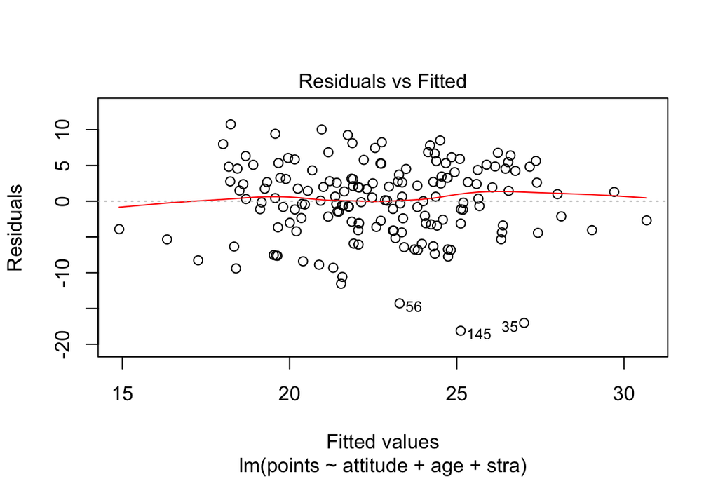

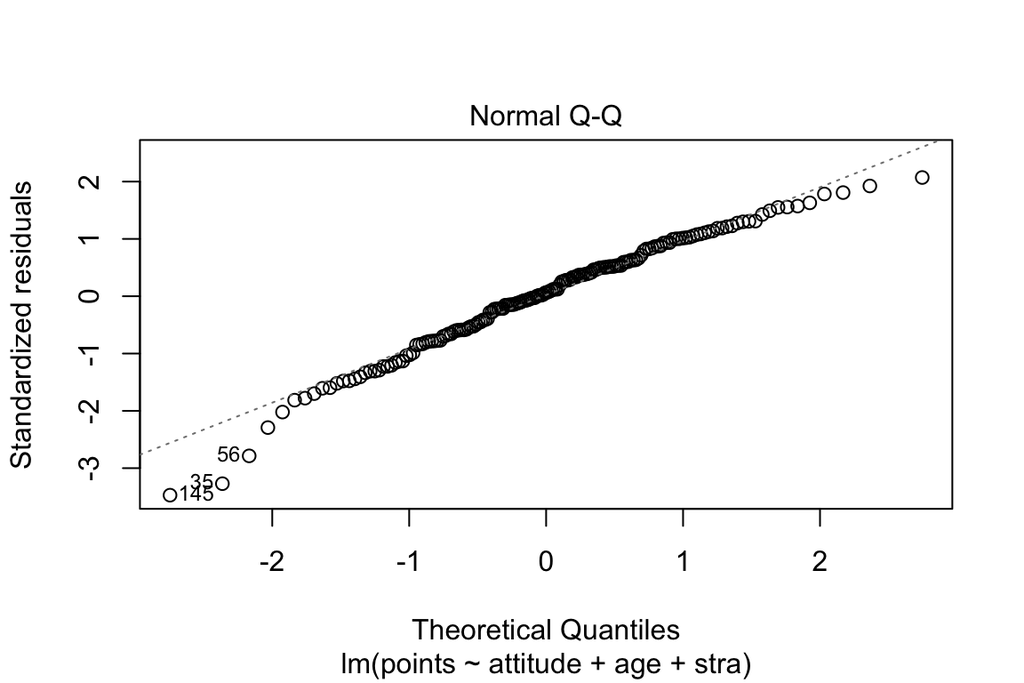

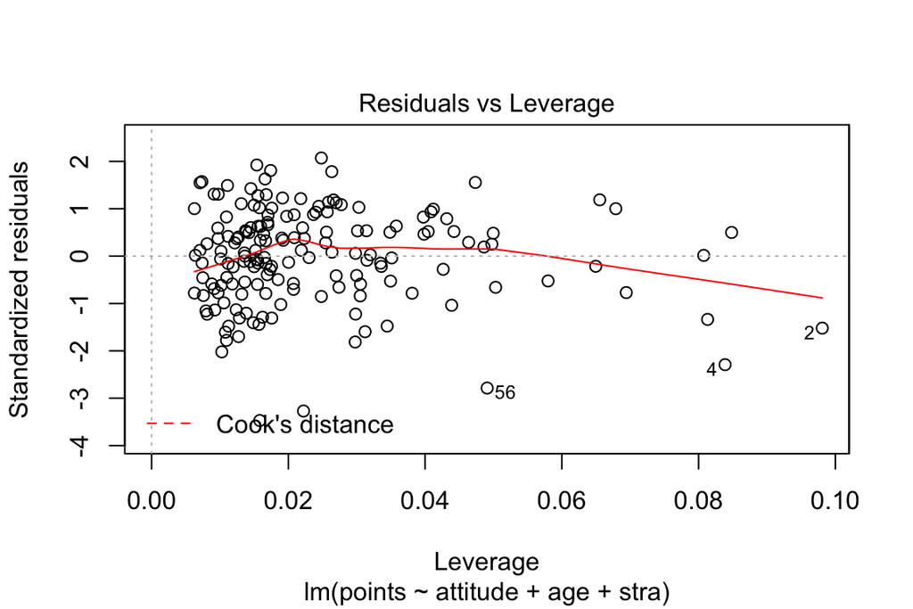

```r
plot(model_final, which = (c(1, 2, 5)))
```

#### From the diagnostic plots, we can see the following:

- in ‘Residuals’, the mean of residuals (i.e. the difference between predicted and observed values of ‘points’) is close to zero in all fitted values (in x-axis). There is not a linear, neither non-linear pattern in residuals. Some outliers (cases 56, 145, 35) are indicated.
- in ‘Normal Q-Q’ plot, all the residuals are beautifully lined. Same outliers are indicated
- in ‘Residuals vs. Leverage’, all the cases are well inside the Cook’s distance, which means that even the outliers follow the pattern of other data points, and that they should not change the model too much. in fact, the limit values of Cook’s distance fall outside of the plot’s range.

```r
#create a directory path, where the data is located
path <- paste(getwd(), "data", "alcohol", sep = "/")

#create the data
alc <- read.csv(path)
colnames(alc)
```

```
##  [1] "X"          "school"     "sex"        "age"        "address"
##  [6] "famsize"    "Pstatus"    "Medu"       "Fedu"       "Mjob"
## [11] "Fjob"       "reason"     "nursery"    "internet"   "guardian"
## [16] "traveltime" "studytime"  "failures"   "schoolsup"  "famsup"
## [21] "paid"       "activities" "higher"     "romantic"   "famrel"
## [26] "freetime"   "goout"      "Dalc"       "Walc"       "health"
## [31] "absences"   "G1"         "G2"         "G3"         "alc_use"
## [36] "high_use"
```

```r
glimpse(alc)
```

```
## Observations: 382
## Variables: 36
## $ X          <int> 1, 2, 3, 4, 5, 6, 7, 8, 9, 10, 11, 12, 13, 14, 15, ...
## $ school     <fctr> GP, GP, GP, GP, GP, GP, GP, GP, GP, GP, GP, GP, GP...
## $ sex        <fctr> F, F, F, F, F, M, M, F, M, M, F, F, M, M, M, F, F,...
## $ age        <int> 18, 17, 15, 15, 16, 16, 16, 17, 15, 15, 15, 15, 15,...
## $ address    <fctr> U, U, U, U, U, U, U, U, U, U, U, U, U, U, U, U, U,...
## $ famsize    <fctr> GT3, GT3, LE3, GT3, GT3, LE3, LE3, GT3, LE3, GT3, ...
## $ Pstatus    <fctr> A, T, T, T, T, T, T, A, A, T, T, T, T, T, A, T, T,...
## $ Medu       <int> 4, 1, 1, 4, 3, 4, 2, 4, 3, 3, 4, 2, 4, 4, 2, 4, 4, ...
## $ Fedu       <int> 4, 1, 1, 2, 3, 3, 2, 4, 2, 4, 4, 1, 4, 3, 2, 4, 4, ...
## $ Mjob       <fctr> at_home, at_home, at_home, health, other, services...
## $ Fjob       <fctr> teacher, other, other, services, other, other, oth...
## $ reason     <fctr> course, course, other, home, home, reputation, hom...
## $ nursery    <fctr> yes, no, yes, yes, yes, yes, yes, yes, yes, yes, y...
```

[output cut: 23 more lines]

#### Data

‘alc’ is a dataset of students portugese schools, about their performance in two subjects, mathematics and portugese language. It contains variables on students’ education, family, school performance, and alcohol use, which is a special interest in this report.  
For exploration, let’s create two datasets - alc_col and alc_other. Alc_col contains factors, alc_other supposedly continuous variables. As “failures” -variable seems to be 4-level, let’s add it to alc_cols as well.

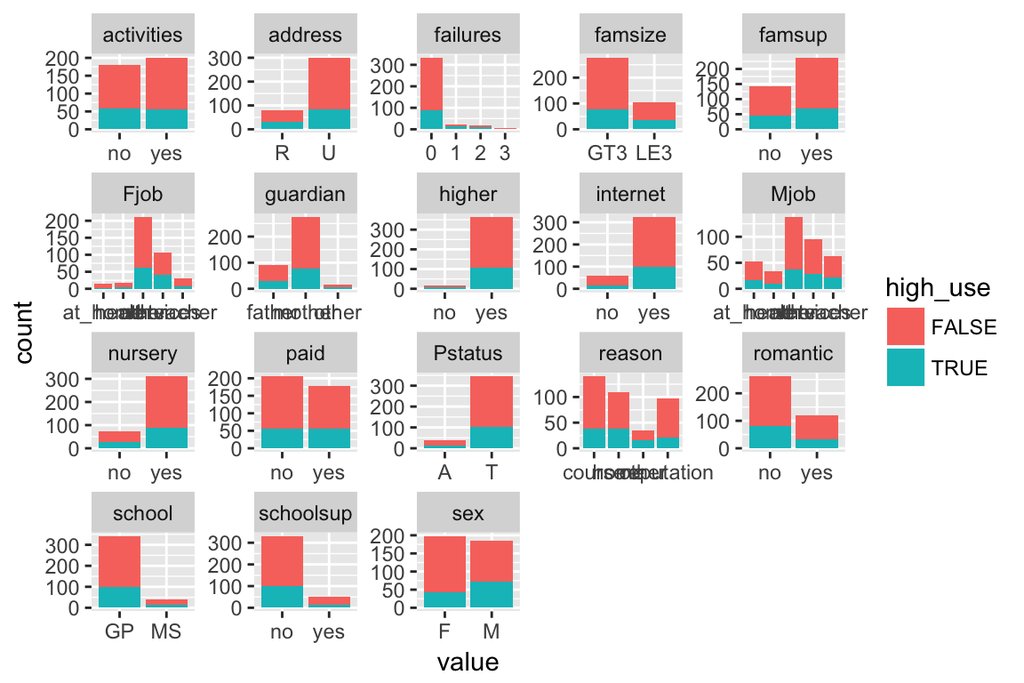

```r
#make indices which variables are columns and which are other than columns
alc_colinds <- which(map_lgl(alc, is.factor))
alc_col <- dplyr::select(alc, alc_colinds, failures, high_use)
alc_other <- dplyr::select(alc, -alc_colinds, -failures, high_use)


#plot explorative plots

alc_col %>% gather(key, value, -high_use) %>%
  ggplot(., aes(x=value, fill = high_use)) + geom_bar() +
   facet_wrap("key", scales = "free", shrink = TRUE)
```

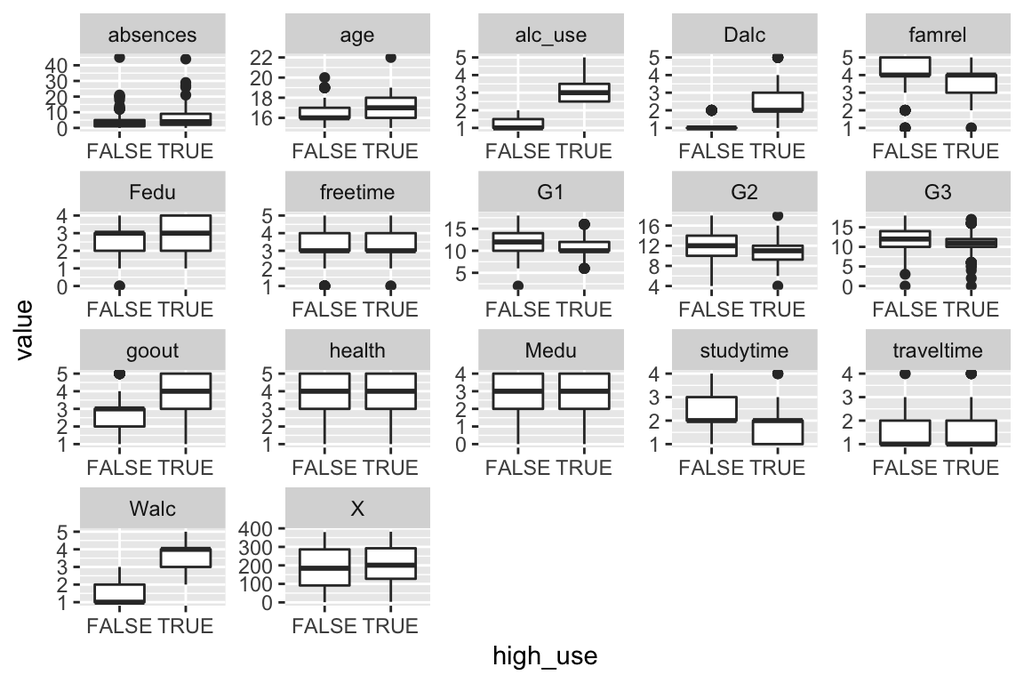

```r
alc_other %>% gather(key, value, -high_use) %>%
  ggplot(., aes(x=high_use, y=value)) + geom_boxplot() +
  facet_wrap("key", scales = "free", shrink = T)
```

#### Interesting variables

We select 4 interesting variables for analysis, let they be: famrel, sex, absences, goout.

Let’s do some exploratory analyses with these variables - we look at the possible differences in high and low alcohol consumption groups.

```r
# create a dataset with the variables of interest
 alc_log <- alc %>%
  dplyr::select(famrel, sex, absences, goout, high_use)

#exploratory table
CreateTableOne(data = alc_log, strata = "high_use", vars = c("famrel", "sex", "absences", "goout"))
```

```
##                       Stratified by high_use
##                        FALSE        TRUE         p      test
##   n                     268          114
##   famrel (mean (sd))   4.00 (0.89)  3.78 (0.93)   0.027
##   sex = M (%)           112 (41.8)    72 (63.2)  <0.001
##   absences (mean (sd)) 3.71 (4.45)  6.37 (6.99)  <0.001
##   goout (mean (sd))    2.85 (1.02)  3.72 (1.10)  <0.001
```

In all our variables, there appears to be a statistically significant difference in either the ratio of heavy drinkers, or the mean value of continuous variable is different in those who drink much.

### The logistic regression model

```r
modbin <- glm(data = alc_log, high_use ~ famrel + sex + absences + goout, family = "binomial")

#look at the model
summary(modbin)
```

```
##
## Call:
## glm(formula = high_use ~ famrel + sex + absences + goout, family = "binomial",
##     data = alc_log)
##
## Deviance Residuals:
##     Min       1Q   Median       3Q      Max
## -1.7151  -0.7820  -0.5137   0.7537   2.5463
##
## Coefficients:
##             Estimate Std. Error z value Pr(>|z|)
## (Intercept) -2.76826    0.66170  -4.184 2.87e-05 ***
## famrel      -0.39378    0.14035  -2.806 0.005020 **
## sexM         1.01234    0.25895   3.909 9.25e-05 ***
## absences     0.08168    0.02200   3.713 0.000205 ***
## goout        0.76761    0.12316   6.232 4.59e-10 ***
## ---
## Signif. codes:  0 '***' 0.001 '**' 0.01 '*' 0.05 '.' 0.1 ' ' 1
##
## (Dispersion parameter for binomial family taken to be 1)
##
##     Null deviance: 465.68  on 381  degrees of freedom
## Residual deviance: 379.81  on 377  degrees of freedom
## AIC: 389.81
##
## Number of Fisher Scoring iterations: 4
```

```r
#calculate CI's
modbin_odds <- exp(cbind(OR = coef(modbin), confint(modbin)))
modbin_odds
```

```
##                     OR      2.5 %    97.5 %
## (Intercept) 0.06277092 0.01648406 0.2225470
## famrel      0.67449969 0.51060362 0.8869199
## sexM        2.75203774 1.66768032 4.6128191
## absences    1.08510512 1.04012840 1.1353940
## goout       2.15461275 1.70345866 2.7639914
```

All the variables are significantly associated with high alcohol use. Family relations are inversely related - the better the family relations, the lower the odds for drinking are. Being male increases the OR to 2,8. Absences and going out are related to higher chance of high alcohol use.

### Prediction

```r
#let's add the probabilities to data frame
alc_pred <- alc %>%
  mutate(prob = predict(modbin, type = "response")) %>%
  mutate(pred = prob>0.5)
#table
obs_table <- table(high_use = alc_pred$high_use, prediction = alc_pred$pred)
prob_table <- obs_table %>% prop.table %>% addmargins

obs_table
```

```
##         prediction
## high_use FALSE TRUE
##    FALSE   254   14
##    TRUE     64   50
```

```r
prob_table
```

```
##         prediction
## high_use      FALSE       TRUE        Sum
##    FALSE 0.66492147 0.03664921 0.70157068
##    TRUE  0.16753927 0.13089005 0.29842932
##    Sum   0.83246073 0.16753927 1.00000000
```

in ’obs_table, the number of “true positives” is 50, and “false positives” is 14. “True negatives” are 254, and “false negatives” are 64. In prob_table, 66% were classified rightly as non-high drinkers, 16% were classified wrongly to non-high drinkers; 3% were classified wrongly as high-drinkers, and 13% were rightly assigned a high-drinker status.

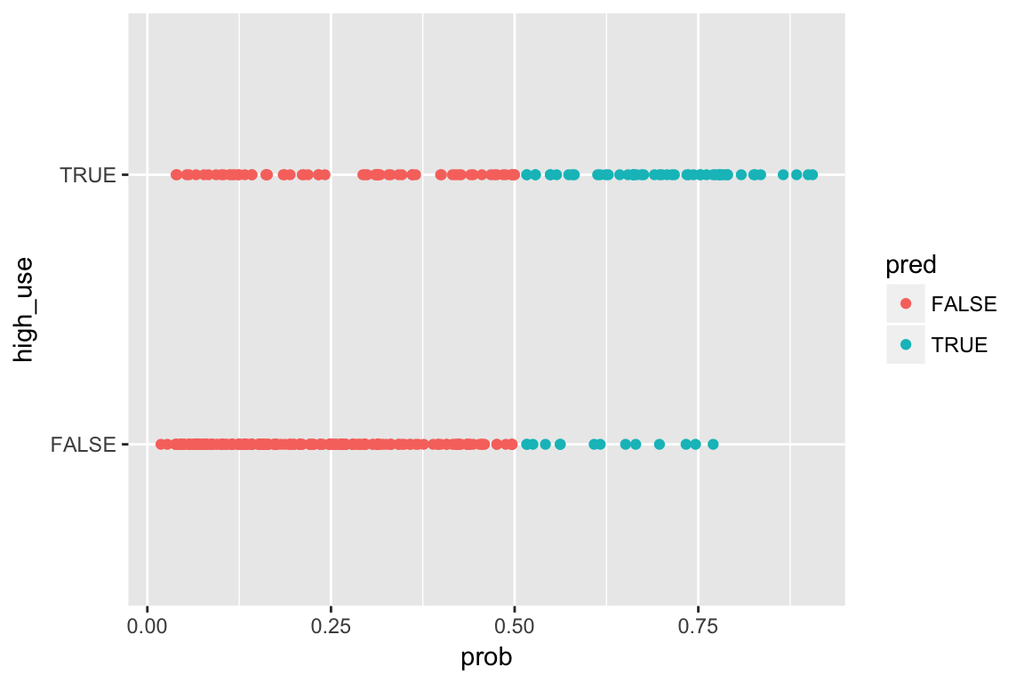

```r
#visualise the relation
ggplot(alc_pred, aes(x = prob, y = high_use, col = pred)) + geom_point()
```

we see that in high drinkers, the number of false predictions is rather high.

### Proportion of false predictions

```r
#define the loss function
loss_func <- function(class = alc_pred$high_use, prob) {
  n_wrong <- abs(class - prob) > 0.5
  mean(n_wrong)
}

# apply the loss function to different prediction strategies
# probability of high drinking is 0 in all
loss_func(prob=0)
```

```
## [1] 0.2984293
```

```r
# probability of high drinking is 1 in all
loss_func(prob=1)
```

```
## [1] 0.7015707
```

```r
loss_func(prob = alc_pred$prob)
```

```
## [1] 0.2041885
```

If we guess at randomly that students are non-high drinkers, the prediction error is around 30%. If we think that everyone are high drinkers, the error is 70%. With our model, the training error is “only” 20%

### Cross-validation

```r
library(boot)
cv <- cv.glm(data = alc_pred, cost = loss_func, glmfit = modbin, K = 10)
cv$delta[1]
```

```
## [1] 0.2015707
```

#### SUPER-BONUS

```r
library(boot)
colnames(alc)
```

```
##  [1] "X"          "school"     "sex"        "age"        "address"
##  [6] "famsize"    "Pstatus"    "Medu"       "Fedu"       "Mjob"
## [11] "Fjob"       "reason"     "nursery"    "internet"   "guardian"
## [16] "traveltime" "studytime"  "failures"   "schoolsup"  "famsup"
## [21] "paid"       "activities" "higher"     "romantic"   "famrel"
## [26] "freetime"   "goout"      "Dalc"       "Walc"       "health"
## [31] "absences"   "G1"         "G2"         "G3"         "alc_use"
## [36] "high_use"
```

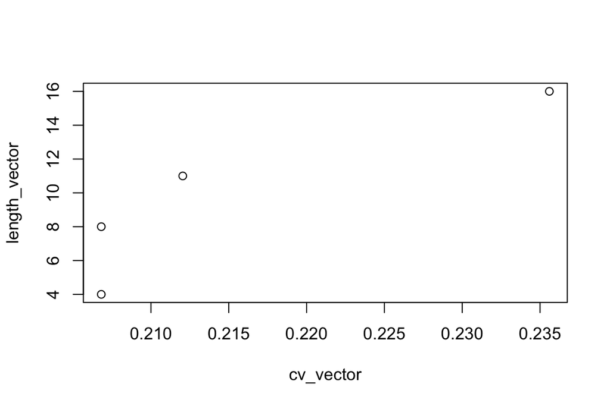

```r
#2nd model
modbin2 <- glm(data=alc, high_use ~ sex + school + age + address + famsize + Pstatus + reason + internet + failures + schoolsup +
                  activities + romantic + freetime + goout + absences + G3, family = "binomial")


prob2 <- predict(modbin2, type = "response")
train2 <- loss_func(prob=prob2)

cv2 <- cv.glm(data=alc_pred, cost = loss_func, glmfit = modbin2, K = 10)

#3rd model
modbin3 <- glm(data=alc, high_use ~ sex + school + age  + failures + schoolsup +
                  activities + romantic + freetime + goout + absences + G3, family = "binomial")


prob3 <- predict(modbin3, type = "response")
train3 <- loss_func(prob=prob3)

cv3 <- cv.glm(data=alc_pred, cost = loss_func, glmfit = modbin3, K = 10)

#4th model
modbin4 <- glm(data=alc, high_use ~ sex + school + schoolsup + reason + activities + goout + freetime + absences, family = "binomial")

prob4 <- predict(modbin4, type = "response")
train4 <- loss_func(prob=prob4)

cv4 <- cv.glm(data=alc_pred, cost = loss_func, glmfit = modbin4, K = 10)


#5th model
modbin5 <- glm(data=alc, high_use ~ sex  + activities + goout + absences, family = "binomial")

prob5 <- predict(modbin5, type = "response")
train5 <- loss_func(prob=prob5)

cv5 <- cv.glm(data=alc_pred, cost = loss_func, glmfit = modbin5, K = 10)


#now create a vector of testing errors and training errors
cv_vector <- c(cv2$delta[1], cv3$delta[1], cv4$delta[1], cv5$delta[1])
train_vector <- c(train2, train3, train4, train5)

length_vector <- c(16, 11, 8, 4)


plot(cv_vector, length_vector)
```

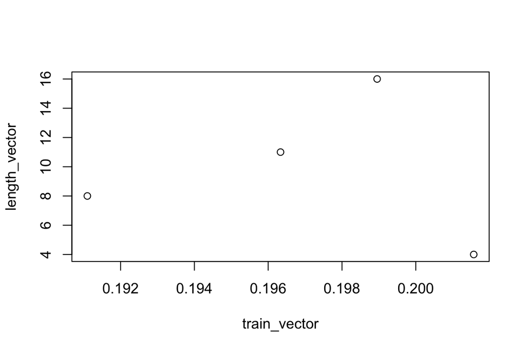

```r
plot(train_vector, length_vector)
```

The trend in testing error (calculated with 10-fold cross-validation) appears to be increasing as the number of variables goes up. The training error is not necessarily so, as with 4 predictors the training error appears to be greater….

Thanks for reading!